# Price Sensitivity, Seasonality, and Sales Performance Across Rainoil Retail Outlets: An Exploratory and Inferential Analysis of 2024–2025 Fuel Sales Data

## 5.2 Data Quality Issues

```r
# Issue 1: Missing / zero price values
missing_prices <- stations_long |>
  summarise(
    `Missing PMS Price` = sum(is.na(pms_price)),
    `Missing AGO Price` = sum(is.na(ago_price)),
    `Zero DPK Volume` = sum(dpk_vol == 0, na.rm = TRUE),
    `Zero PMS Volume` = sum(pms_vol == 0, na.rm = TRUE)
  )

kable(missing_prices, caption = "Data Quality Flags") |>
  kable_styling(bootstrap_options = "striped", full_width = FALSE)
```

Data Quality Flags

| Missing PMS Price | Missing AGO Price | Zero DPK Volume | Zero PMS Volume |
| --- | --- | --- | --- |
| 145 | 145 | 3291 | 168 |

```r
# Issue 1: Missing / zero price values
missing_prices <- stations_long |>
  summarise(
    `Missing PMS Price`  = sum(is.na(pms_price)),
    `Missing AGO Price`  = sum(is.na(ago_price)),
    `Zero PMS Volume`    = sum(pms_vol == 0, na.rm = TRUE),
    `Zero DPK Volume`    = sum(dpk_vol == 0, na.rm = TRUE)
  )

kable(missing_prices, caption = "Data Quality Flags — 193 Stations × 24 Months") |>
  kable_styling(bootstrap_options = "striped", full_width = FALSE)
```

Data Quality Flags — 193 Stations × 24 Months

| Missing PMS Price | Missing AGO Price | Zero PMS Volume | Zero DPK Volume |
| --- | --- | --- | --- |
| 145 | 145 | 168 | 3291 |

```r
# Issue 2: New stations commissioned mid-2025 (start later than Jan 2024)
ramp_up <- stations_long |>
  filter(year == 2025) |>
  group_by(station_name, area) |>
  summarise(first_active_month = min(month[operational], na.rm = TRUE),
            months_active_2025 = sum(operational, na.rm = TRUE),
            .groups = "drop") |>
  filter(months_active_2025 < 12) |>
  arrange(months_active_2025)

cat("\nStations that opened mid-2025 (fewer than 12 active months):\n")
```

```
Stations that opened mid-2025 (fewer than 12 active months):
```

```r
print(ramp_up, n = 20)
```

```
# A tibble: 18 × 4
   station_name                    area    first_active_month months_active_2025
   <chr>                           <chr>   <ord>                           <int>
 1 Rainoil Ughelli Post Office     Ughelli Dec                                 1
 2 Rainoil Uselu Shell             Benin   Nov                                 2
 3 Rainoil Aba - Faulks Road       South-… Oct                                 3
 4 Rainoil Ughelli Otovwodo        Ughelli Sep                                 4
 5 Rainoil Eboh Road               Warri   Jul                                 6
 6 Rainoil Lafia                   North … Jul                                 6
 7 Rainoil Patani                  Ughelli Jul                                 6
 8 Fynefield Abak Town             Calaba… Jun                                 7
 9 Rainoil Giwa-Amu                Warri   May                                 8
10 Rainoil Ilorin - Sobi Road      South-… Jan                                 9
11 Rainoil North Bank              North … Apr                                 9
12 Rainoil Ugbolu                  Delta   Apr                                 9
13 Rainoil Gboko                   North … Jan                                10
14 Rainoil Ogbomosho               South-… Mar                                10
15 Rainoil Portharcourt - Igwuruta Calaba… Jan                                10
16 Rainoil Lokoja                  Fct     Jan                                11
17 Rainoil Osubi - Airport Road    Warri   Feb                                11
18 Rainoil Yenagoa Kpansia         Yenagoa Feb                                11
```

> **Handling:** (1) Missing pump prices (where stations recorded zero for AVG PRICE) are replaced with `NA` rather than zero to avoid distorting price analysis — they are excluded from the regression on a listwise basis. (2) Stations with zero PMS across several months (e.g. Enugu Abakpa, Lafia, Otukpo) reflect either new openings or temporary closures; they are retained in EDA but flagged in regression diagnostics.

## 5.3 Outlier Detection — Top and Bottom Stations

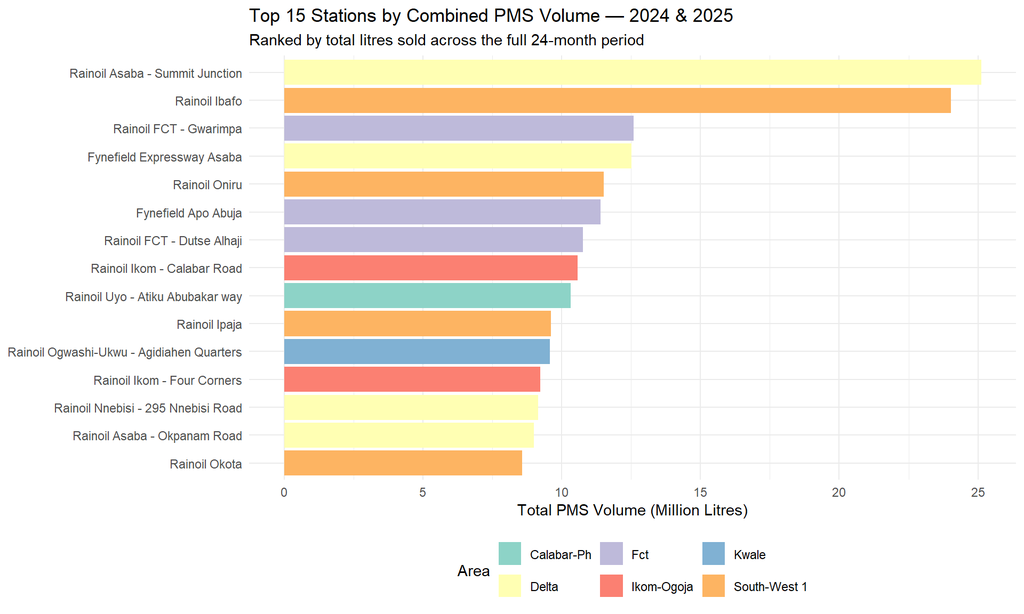

```r
annual_pms <- stations_long |>
  group_by(station_name, area, zone, year) |>
  summarise(total_pms = sum(pms_vol, na.rm = TRUE),
            total_ago = sum(ago_vol, na.rm = TRUE),
            months_active = sum(operational, na.rm = TRUE),
            .groups = "drop") |>
  arrange(desc(total_pms))

# 2024 baseline for charts that need a single-year ranking
annual_pms_2024 <- annual_pms |> filter(year == 2024)
# All-time ranking (sum across both years)
annual_pms_all  <- annual_pms |>
  group_by(station_name, area, zone) |>
  summarise(total_pms = sum(total_pms), .groups = "drop") |>
  arrange(desc(total_pms))

# Top 15 stations by 2024 annual PMS volume
top15 <- annual_pms_all |> slice_head(n = 15)

top15 |>
  ggplot(aes(x = reorder(station_name, total_pms),
             y = total_pms / 1e6, fill = area)) +
  geom_col() +
  coord_flip() +
  scale_y_continuous(labels = label_comma()) +
  scale_fill_brewer(palette = "Set3") +
  labs(title = "Top 15 Stations by Combined PMS Volume — 2024 & 2025",
       subtitle = "Ranked by total litres sold across the full 24-month period",
       x = NULL, y = "Total PMS Volume (Million Litres)", fill = "Area") +
  theme_minimal(base_size = 11) +
  theme(legend.position = "bottom")
```

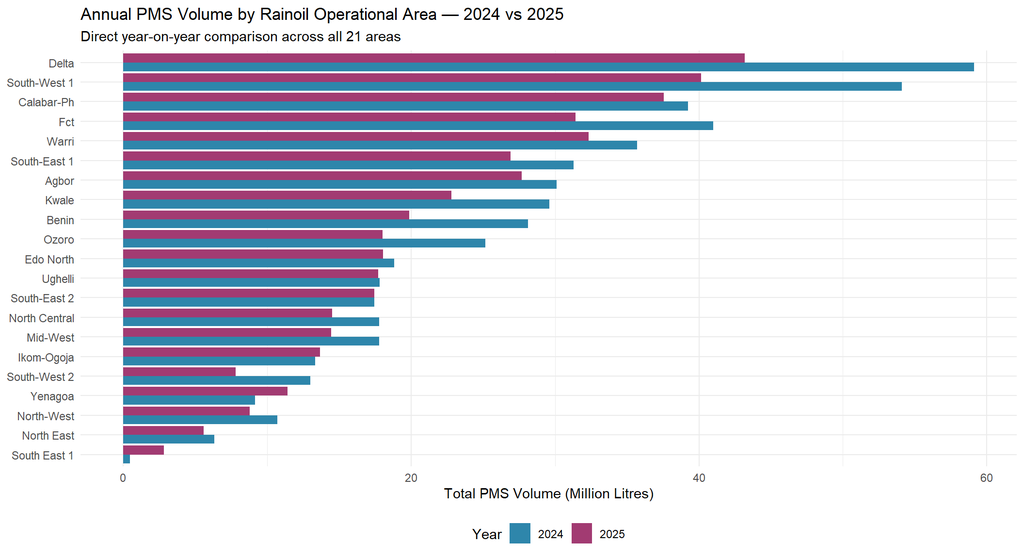

```r
# Area-level annual PMS comparison 2024 vs 2025
stations_long |>
  group_by(area, year) |>
  summarise(total_pms = sum(pms_vol, na.rm = TRUE) / 1e6, .groups = "drop") |>
  ggplot(aes(x = reorder(area, total_pms),
             y = total_pms, fill = factor(year))) +
  geom_col(position = "dodge") +
  coord_flip() +
  scale_fill_manual(values = c("2024" = "#2E86AB", "2025" = "#A23B72")) +
  scale_y_continuous(labels = label_comma()) +
  labs(title = "Annual PMS Volume by Rainoil Operational Area — 2024 vs 2025",
       subtitle = "Direct year-on-year comparison across all 21 areas",
       x = NULL, y = "Total PMS Volume (Million Litres)", fill = "Year") +
  theme_minimal(base_size = 11) +
  theme(legend.position = "bottom")
```

> **Interpretation:** Summit Junction (Asaba) and Ibafo (Lagos) are clear network outliers — each selling over 10 million litres annually, roughly 5–8× the network median. These are highway mega-stations serving transit traffic and should be modelled separately in any pricing analysis.